[figure not shown]

# distributions7

[figure not shown]

Almost every R package that fits statistical models writes its own distributions, privately: a `switch` on a character string, a list of closures nobody outside can reach. So the same Gamma gets re-implemented again and again, and each time only as far as that package happened to need — the density and the score, sometimes the Hessian, rarely anything beyond.

`{distributions7}` writes them once, as objects. Each carries the usual density, distribution and quantile functions, and the **exact derivatives of the log-likelihood up to fourth order** — with respect to the parameters, with respect to the response, and with respect to the unconstrained parameters behind a link function, which is the scale an optimiser actually works on.

It is the distribution layer of [statmodels7](https://statmodels7.github.io), an S7 stack for statistical modelling, and works alongside linkfunctions7.

## Installation

```r
# install.packages("pak")
pak::pak("statmodels7/distributions7")
```

## The usual functions

Fourteen distributions ship with the package. Each constructor takes the link functions used for its parameters, and parameters travel as a named list.

```r
d <- gaussian_distrib()
theta <- list(mu = 2, sigma = 3)

distrib_pdf(d, c(0, 2, 4), theta)
```

```
#> [1] 0.1064827 0.1329808 0.1064827
```

```r
distrib_cdf(d, c(0, 2, 4), theta)
```

```
#> [1] 0.2524925 0.5000000 0.7475075
```

```r
distrib_quantile(d, c(0.025, 0.5, 0.975), theta)
```

```
#> [1] -3.879892  2.000000  7.879892
```

## Derivatives, which is the point

The score, the observed and expected information, and third and fourth order derivatives are all closed form.

```r
y <- distrib_rng(d, 5, theta)

distrib_gradient(d, y, theta)
```

```
#> $mu
#> [1] -0.20881794  0.06121444 -0.27854287  0.53176027  0.10983592
#>
#> $sigma
#> [1] -0.2025185 -0.3220917 -0.1005749  0.5149736 -0.2971415
```

```r
distrib_expected_hessian(d, 0, theta)
```

```
#> $mu_mu
#> [1] -0.1111111
#>
#> $sigma_sigma
#> [1] -0.2222222
#>
#> $mu_sigma
#> [1] 0
```

Ask for them on the **link scale** and you get derivatives with respect to the unconstrained parameters instead, through the chain rule rather than by differentiating numerically:

```r
distrib_gradient(d, y, theta, scale = "link")
```

```
#> $mu
#> [1] -0.20881794  0.06121444 -0.27854287  0.53176027  0.10983592
#>
#> $sigma
#> [1] -0.6075556 -0.9662751 -0.3017248  1.5449208 -0.8914246
```

## Fitting

`fit_distrib()` maximises the likelihood on the link scale, where the parameters are unconstrained, then reports estimates back on their natural scale. Confidence intervals are built on the link scale and mapped through $g^{-1}$, so they can never leave a parameter’s domain.

```r
y <- distrib_rng(gamma_distrib(), 500, list(mu = 3, sigma2 = 2))
fit <- fit_distrib(gamma_distrib(), y)
fit
```

```
#> Maximum-likelihood fit: gamma
#> Observations: 500   Log-likelihood: -841.2   AIC: 1686   BIC: 1695
#> Method: Fisher scoring (converged in 17 iterations)
#>
#> Parameter scale (95% CI mapped from the link scale):
#>        Estimate Std. Error   2.5%  97.5%
#> mu       2.9570     0.0631 2.8359 3.0832
#> sigma2   1.9888     0.1480 1.7188 2.3011
#>
#> Link scale (log, log):
#>        Estimate Std. Error
#> mu       1.0842     0.0213
#> sigma2   0.6875     0.0744
```

The fit knows what it was estimated from, so it can be checked against the data and simulated from:

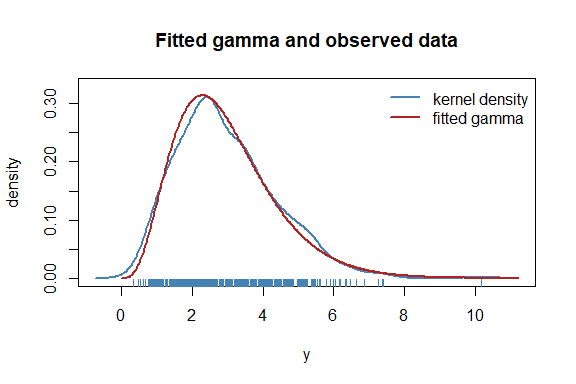

```r
plot(fit)
```

```r
sims <- simulate(fit, 100, seed = 1)
quantile(vapply(sims, median, numeric(1)), c(0.025, 0.975))
```

```
#>     2.5%    97.5%
#> 2.570081 2.881259
```

## A distribution of your own needs only its density

Everything above has a numerical fallback registered on the base classes: the distribution function by quadrature, the quantile function by root finding, the generator by Generalized Ratio-of-Uniforms, and every derivative by finite differences. So a new distribution is a subclass and one method.

```r
MyLaplace <- S7::new_class("MyLaplace", parent = continuous_distrib)

S7::method(distrib_pdf, MyLaplace) <- function(distrib, y, theta, log = FALSE) {
  ld <- -log(2 * theta$b) - abs(y - theta$mu) / theta$b
  if (log) ld else exp(ld)
}

d2 <- MyLaplace(
  distrib_name = "my laplace", dimension = "univariate", bounds = c(-Inf, Inf),
  params = c("mu", "b"), params_interpretation = c(mu = "location", b = "scale"),
  n_params = 2, params_bounds = list(mu = c(-Inf, Inf), b = c(0, Inf)),
  link_params = list(
    mu = linkfunctions7::identity_link(),
    b  = linkfunctions7::log_link()
  )
)

# never implemented, yet available
distrib_cdf(d2, 1, list(mu = 0, b = 2))
```

```
#> [1] 0.6967347
```

```r
distrib_gradient(d2, 1, list(mu = 0, b = 2))
```

```
#> $mu
#> [1] 0.5
#>
#> $b
#> [1] -0.25
```

See `vignette("defining-a-distribution")` for the full treatment, including what to do when a parameter is not differentiable.

## Checking your work

`check_distrib()` puts a distribution through thirteen numerical checks: that the density integrates to one, that the distribution function agrees with it, that the quantile function inverts it, that the generator follows it, and that every derivative order matches finite differences — on both scales.

```r
invisible(check_distrib(d2, list(mu = 0, b = 2), nsim = 2e4))
```

```
#> Distribution: my laplace
#> Parameters:   mu = 0, b = 2
#> Observations: 100   Monte Carlo: 20000
#>
#>   [OK  ] density integrates to 1                     1.81e-10
#>   [OK  ] density is non-negative                     5.00e-03
#>   [OK  ] cdf in [0,1] and non-decreasing             2.46e-02
#>   [OK  ] cdf agrees with the density                 8.42e-06
#>   [OK  ] quantile/cdf round-trip                     3.31e-10
#>   [OK  ] rng matches the cdf                         1.75e+00
#>   [OK  ] gradient vs finite differences              0.00e+00
#>   [OK  ] hessian vs finite differences               0.00e+00
#>   [OK  ] deriv3 vs finite differences                0.00e+00
#>   [OK  ] deriv4 vs finite differences                0.00e+00
#>   [OK  ] expected information vs Monte Carlo         1.32e+00
#>   [OK  ] response derivatives vs finite differences  0.00e+00
#>   [OK  ] link-scale gradient vs finite differences   3.07e-09
#>
#> All 13 checks passed.
```

## What is in the box

| continuous | gaussian, cauchy, logistic, Student’s t, Laplace, pseudo-Huber, gamma, inverse gaussian, lognormal, beta |
| --- | --- |
| discrete | bernoulli, binomial, poisson, negative binomial |
| wrappers | `zero_inflated()`, `zero_adjusted()`, `transformation()` with twelve transformers |
| tools | `fit_distrib()`, `check_distrib()`, `expectation()`, moments, `rng_grou()` |